# KwaThunzi runoff time-series simulation

Christian Sommer

## Content

This is a an R script to simulate a runoff time-series based on empirical data for the DYNGUL gully model by Alexey Sidorchuk (1998, 1999). In a first step, observed runoff data are transformed and a temporaly variable gaussian function is derived. In a second step, random values are created from this function in a reproducible manner, to create a simulated long-term time series, which resembles the natural conditions. The simulated time-series reflects the conditions of the observed data, *without effects like climate change or land use / land cover change, etc*. In the final step, data are exportet in a structered text file, which is ready-to-use with the DYNGUL implementation.

### Units

| Name | Abbr | Unit |
| --- | --- | --- |
| runoff | Q | m³/s |
| logarithmic runoff | Qlog | log(m³/s) |
| area specific runoff | q | l/(m²s) |
| accumulated daily runoff height | qacc | mm/m² = l/m² per day |

## Calculation

### Data import and preparation

Import the runoff dataset 1960-2018 of the Umkomazi gauging station (ID: U1H005) available at the [South African Department of Water Affairs](http://www.dwa.gov.za/hydrology/Verified/HyDataSets.aspx?Station=U1H005). The runoff Q is in unit [m³/s].

```r
runoff <- read_table2("../data/U1H005_daily.txt",
                      col_types = cols(DATE = col_integer()),
                      skip = 10)
```

```
## # A tibble: 3 x 3
##       DATE     Q  QUAL
##      <int> <dbl> <dbl>
## 1 19600901  2.61     1
## 2 19600902  2.58     1
## 3 19600903  2.56     1
```

We clean the data and set column formats. The quality code indicates the validity of each observation and is available [here](http://www.dwa.gov.za/hydrology/Verified/HyCodes.aspx). Then, we derive seperate columns for ‘year’ and ‘doy’(day-of-year) for each observation with the package [Lubridate](https://lubridate.tidyverse.org)

```r
runoff[is.na(runoff$QUAL),2] <- NA # remove Quality measures that shifted in the Q column
runoff <- ts.format(runoff, format="%Y%m%d", cols=c(1,2)) # set date format
runoff$year <- as.integer(substr(runoff$Date, 1,4)) # derive year
runoff$doy <- as.numeric(strftime(runoff$Date, format = "%j"))  # derive day-of-year
runoff <- na.omit(runoff) # delete empty fields
```

As a result, we get this table…

```
## # A tibble: 3 x 5
##   Date                    Q  QUAL  year   doy
##   <dttm>              <dbl> <dbl> <int> <dbl>
## 1 1960-09-01 00:00:00  2.61     1  1960   245
## 2 1960-09-02 00:00:00  2.58     1  1960   246
## 3 1960-09-03 00:00:00  2.56     1  1960   247
```

… and this continuous dataset of the runoff at the gauging station.

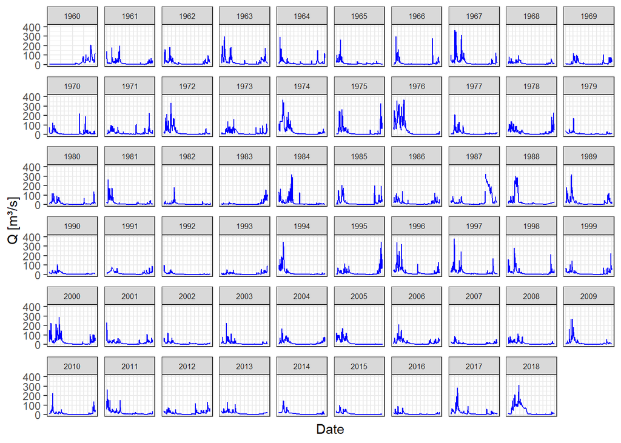

### Runoff transformation and aggregation

We transform the discharge by a base 10 logarithm.

```r
runoff$Qlog <- log10(runoff$Q)  # calculate Log base 10 of runoff
runoff <- runoff[!(runoff$Qlog=='-Inf'),] # delete -Inf
```

```
## # A tibble: 3 x 6
##   Date                    Q  QUAL  year   doy  Qlog
##   <dttm>              <dbl> <dbl> <int> <dbl> <dbl>
## 1 1960-09-01 00:00:00  2.61     1  1960   245 0.416
## 2 1960-09-02 00:00:00  2.58     1  1960   246 0.412
## 3 1960-09-03 00:00:00  2.56     1  1960   247 0.408
```

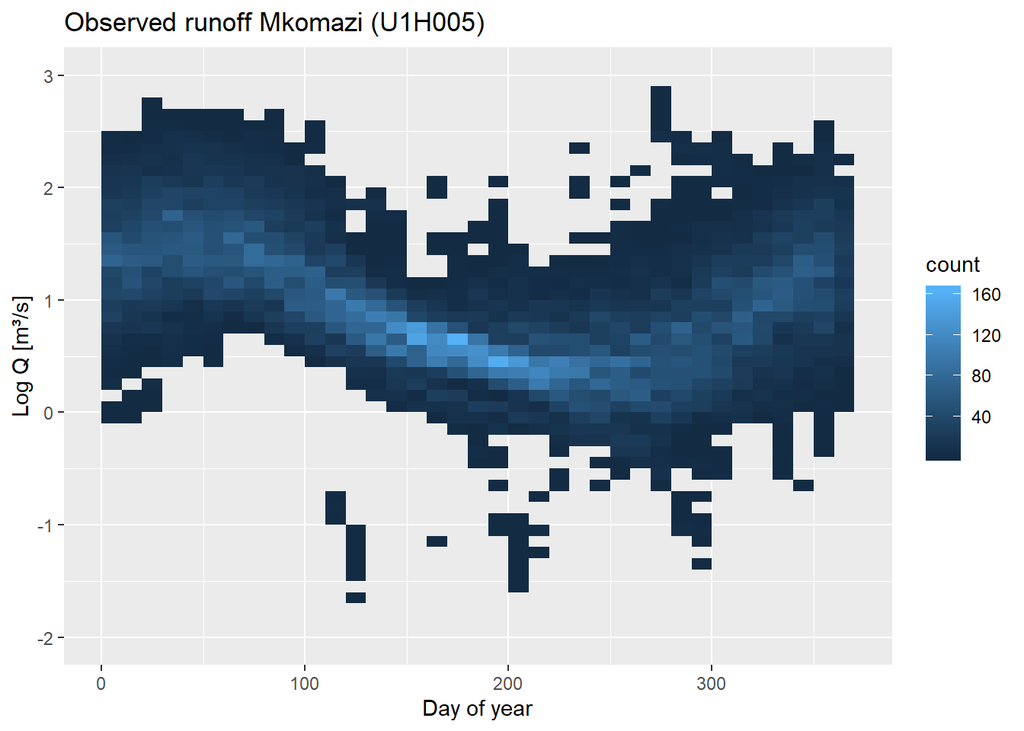

If we plot all of a day-of-year’s discharges, which were measured over the time series, we notice that they follow a normal distribution, when plotted on a logarithmic scale.

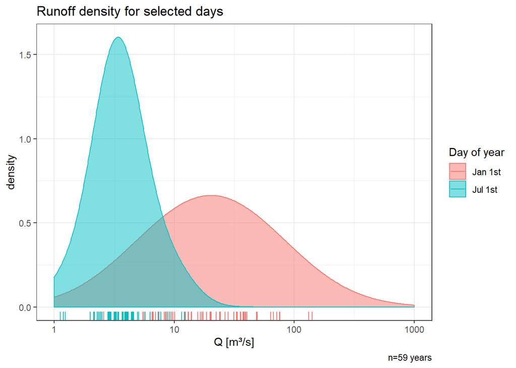

Therefore, we can aptly describe daily runoff patterns through the calculation of mean and standard deviation for each individual day-of-year.

```r
#Create empty data frame
runoff_aggregates <- data.frame()

#aggregate mean runoff per day
runoff_aggregates <- aggregate(runoff, by=list(runoff$doy), FUN=mean)[,c('doy','Qlog')]

#aggregate mean runoff per day
runoff_aggregates$sd <- aggregate(runoff, list(runoff$doy), FUN=sd)[,c('Qlog')]

names(runoff_aggregates) <- c('doy','mean','sd')
```

### Runoff simulation

Now, We simulate expected runoff for each day of any given timeseries, in this example for the range 1500–2018. We create randomized values, based on the observed annual discharge distribution, which was derived from the time series 1960-2018. The random values are derived through a gaussian function from the observed mean and standard deviation.

```r
set.seed(2020)
# Manual input of desired time span
start_year <- 1500
end_year <- 2018
number_of_years <- end_year-start_year
runoff_pred <- data.frame()

# Simulation
for(i in runoff_aggregates$doy){
  x <- rnorm(number_of_years, mean=runoff_aggregates$mean[i], sd=runoff_aggregates$sd[i])
  pred <- data.frame(cbind(seq(start_year,end_year,1), # year
                         rep(i, number_of_years),      # doy
                         x))                           # predicted values
  runoff_pred <- rbind(runoff_pred, pred)
}
names(runoff_pred) <- c('year','doy','Qlog')

# Filter gap years
runoff_pred <- runoff_pred[!(runoff_pred$doy==366 & leap_year(runoff_pred$year)==TRUE),]
```

Here is the resulting distribution of daily discharges. The similarity with the previous illustration of observed data is obvious.

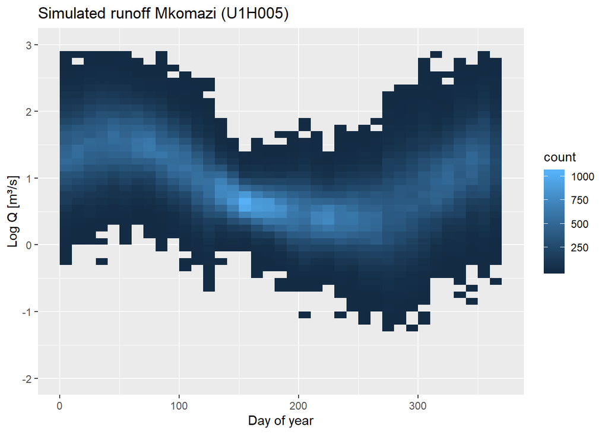

Backtransformation of the logarithmic runoffs to regular Q [m³/s]

```r
runoff_pred$Q <- 10^runoff_pred$Qlog
```

### Calculation of area specific runoff

Until here, we were dealing with runoff values of the gauging station. Now we relate the results to the entire subcatchment area. Therefore, we calculate the **area specific runoff (q)** after Baumgartner & Liebscher (1996) and Casper & Bormann (2016) using
$$\begin{equation}q = \frac{Q}{A}\end{equation}$$
with Q = runoff at the gauging station and A = catchment area

```r
catchment_area <- 1744 * 1000000 # area in [m²]
runoff_pred$q <- runoff_pred$Q/catchment_area
```

```r
runoff_pred$qacc <- runoff_pred$q * 86400 # multiply with secons per day
```

Order rows by year and day-of-year

```r
runoff_pred <- runoff_pred[order(runoff_pred$year, runoff_pred$doy),]
```

```
##      year doy     Qlog        Q            q         qacc
## 1    1500   1 1.449944 28.18022 1.615838e-08 0.0013960842
## 520  1500   2 1.339125 21.83357 1.251925e-08 0.0010816632
## 1039 1500   3 1.854591 71.54699 4.102465e-08 0.0035445300
## 1558 1500   4 1.665231 46.26271 2.652679e-08 0.0022919143
## 2077 1500   5 1.247821 17.69381 1.014553e-08 0.0008765739
## 2596 1500   6 1.669091 46.67577 2.676363e-08 0.0023123776
```

### File Export

Finally, we export the simulated data to a structured file with the two columns ‘year’ and runoff (‘q’ or ‘qacc’), which is ready to use with the gully model.

```r
# Export in [l/(m²s)]
out <- runoff_pred[,c("year", "q")]
out$q <- format(out$q, scientific = FALSE) # change to decimals
write.table(out, "../output/S_150_lts_lm2s.txt", sep="\t", row.names=F, col.names=F, quote=F)
# Export in [mm]
out <- runoff_pred[,c("year", "qacc")]
out$qacc <- format(out$qacc, scientific = FALSE) # change to decimals
write.table(out, "../output/S_150_lts_mm.txt", sep="\t", row.names=F, col.names=F, quote=F)
```

## References

BAUMGARTNER, A. & LIEBSCHER, H. J. 1996. Lehrbuch der Hydrologie, Band 1: Allgemeine Hydologie, Quantitative Hydrologie, Stuttgart, Germany, Schweizerbarth.

CASPER, M. & BORMANN, H. 2016. Abfluss im Gewässersystem. In: FÖHRER, N., BORMANN, H., MIEGEL, K., CASPER, M., BRONSTERT, A., SCHUMANN, A. & WEILER, M. (eds.) Hydrologie. Bern, Switzerland: Haupt.

SIDORCHUK, A. & SIDORCHUK, A. (1998). Model for estimating gully morphology Modelling Soil Erosion, Sediment Transport and Closely Related Hydrological Processes, Vienna.

SIDORCHUK, A. (1999). “Dynamic and static models of gully erosion.” CATENA 37(3): 401-414.